# homework2

```python
import pandas as pd
import numpy as np
import matplotlib.pyplot as plt
import sklearn as skl
import seaborn as sb
```

```python
data_df = pd.read_csv(filepath_or_buffer='data.csv')
```

```python
data_df.head()
```

|  | age | sex | cp | trtbps | chol | fbs | restecg | thalachh | exng | oldpeak | slp | caa | thall | output |
| --- | --- | --- | --- | --- | --- | --- | --- | --- | --- | --- | --- | --- | --- | --- |
| 0 | 63 | 1 | 3 | 145 | 233 | 1 | 0 | 150 | 0 | 2.3 | 0 | 0 | 1 | 1 |
| 1 | 37 | 1 | 2 | 130 | 250 | 0 | 1 | 187 | 0 | 3.5 | 0 | 0 | 2 | 1 |
| 2 | 41 | 0 | 1 | 130 | 204 | 0 | 0 | 172 | 0 | 1.4 | 2 | 0 | 2 | 1 |
| 3 | 56 | 1 | 1 | 120 | 236 | 0 | 1 | 178 | 0 | 0.8 | 2 | 0 | 2 | 1 |
| 4 | 57 | 0 | 0 | 120 | 354 | 0 | 1 | 163 | 1 | 0.6 | 2 | 0 | 2 | 1 |

```python
data_df.info()
```

```
<class 'pandas.core.frame.DataFrame'>
RangeIndex: 303 entries, 0 to 302
Data columns (total 14 columns):
 #   Column    Non-Null Count  Dtype
---  ------    --------------  -----
 0   age       303 non-null    int64
 1   sex       303 non-null    int64
 2   cp        303 non-null    int64
 3   trtbps    303 non-null    int64
 4   chol      303 non-null    int64
 5   fbs       303 non-null    int64
 6   restecg   303 non-null    int64
 7   thalachh  303 non-null    int64
 8   exng      303 non-null    int64
 9   oldpeak   303 non-null    float64
 10  slp       303 non-null    int64
 11  caa       303 non-null    int64
 12  thall     303 non-null    int64
 13  output    303 non-null    int64
dtypes: float64(1), int64(13)
memory usage: 33.3 KB
```

```python
data_df.isnull().sum()
```

```
age         0
sex         0
cp          0
trtbps      0
chol        0
fbs         0
restecg     0
thalachh    0
exng        0
oldpeak     0
slp         0
caa         0
thall       0
output      0
dtype: int64
```

```python
data_df.agg(['nunique']).T
```

|  | nunique |
| --- | --- |
| age | 41 |
| sex | 2 |
| cp | 4 |
| trtbps | 49 |
| chol | 152 |
| fbs | 2 |
| restecg | 3 |
| thalachh | 91 |
| exng | 2 |
| oldpeak | 40 |
| slp | 3 |
| caa | 5 |
| thall | 4 |
| output | 2 |

Step 1.

There are 303 observations.

There are no missing values.

unique values are as follows:

age 41

sex 2

cp 4

trtbps 49

chol 152

fbs 2

restecg 3

thalachh 91

exng 2

oldpeak 40

slp 3

caa 5

thall 4

output 2

Categorical variables are: ['sex' , 'cp' , 'fbs' , 'restecg' , 'exng' , 'slp' , 'output','caa']

Continuous variables are: ['age', 'trtbps','chol','thalachh','oldpeak','thall']

Numerical measurements of vitals are all continuous variables as they can be any number within a specified range and anything in between.

Our categorical variables are not values with a range of multiple outcomes, they are variables assigned 0, 1, or 2 to show which "category" they belong to. For example, you cannot have 1.5 blood vessels, but it is entirely possible to have a maximum heart rate of 142.49

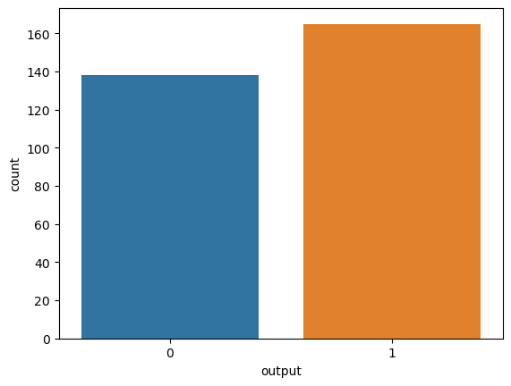

```python
sb.countplot(data_df, x = 'output')
```

Step 2. There is a roughly equal representation of people prone to heart attacks to those who aren't.

Working with a balanced dataset is important depending on what information we are trying to gather. If we are trying to figure out the percentage of population that is at risk for a heart attack, then "balancing" would make our results biased. If we are trying to find which variables help us predict the likelihood of a heart attack (such as this assignment), then a balanced dataset is very important.

We can choose to "fix" an imbalanced dataset by increasing the minority population or reducing the majority population through many means, including deletion, replacement, and resampling.

We can also change our evaluation metric to one that takes into account this imbalanced population, such as f1 scores.

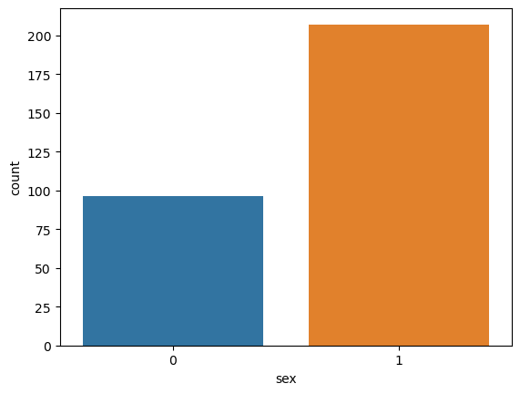

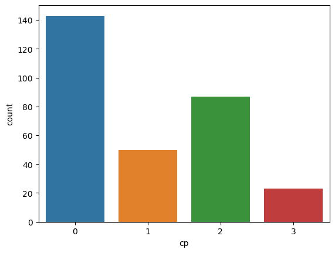

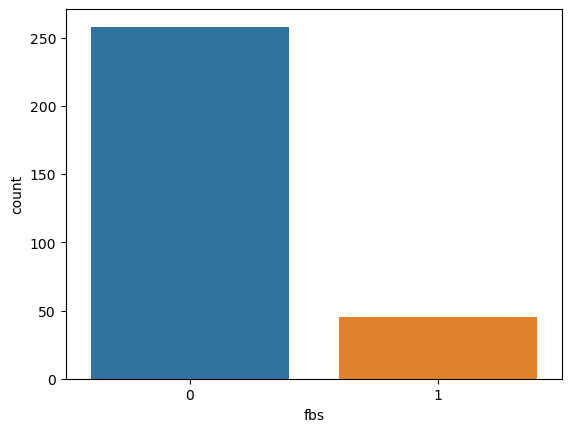

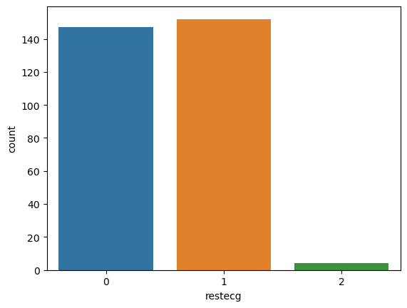

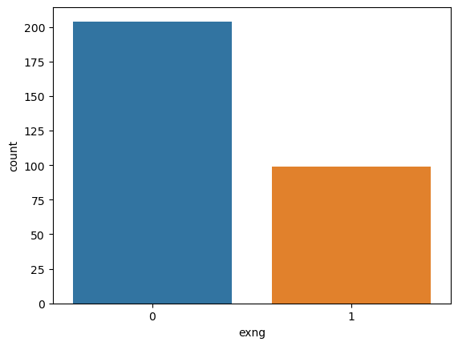

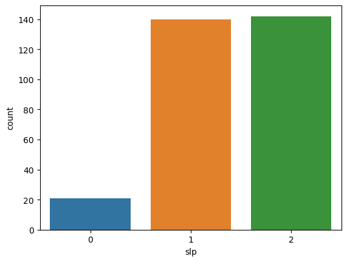

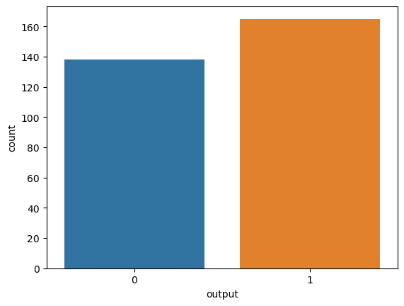

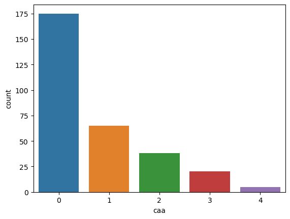

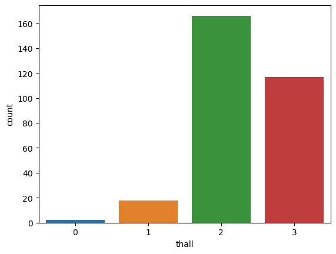

```python
categories = ['sex' , 'cp' , 'fbs' , 'restecg' , 'exng' , 'slp' , 'output','caa','thall']
for i in categories:
    plt.figure() #creates a seperate figure for each count plot
    sb.countplot(data = data_df,x = i)
```

Step 3.

This dataframe does not have much in depth documentation of our variable meanings, but this much I can extrapolate:

Our dataset sampled much more males than females.

Majority of our samples were not sampled using their fasting blood sugar.

Our resting electrocardiograms were 50:50 between type 0 and 1, with very few type 2.

Our slope(?) is evenly split between 1 and 2, very little of 0.

Finally, our at-risk population in our dataset is a little over 55%.

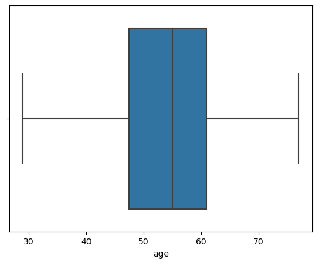

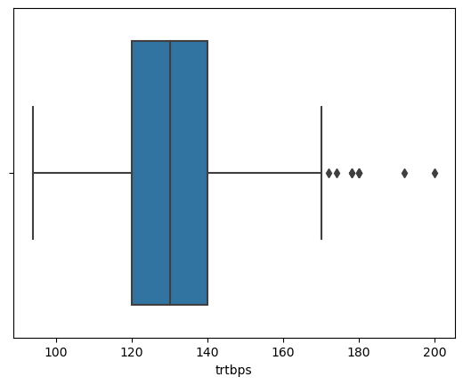

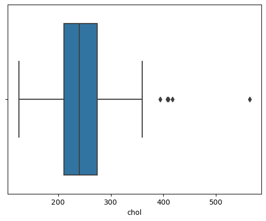

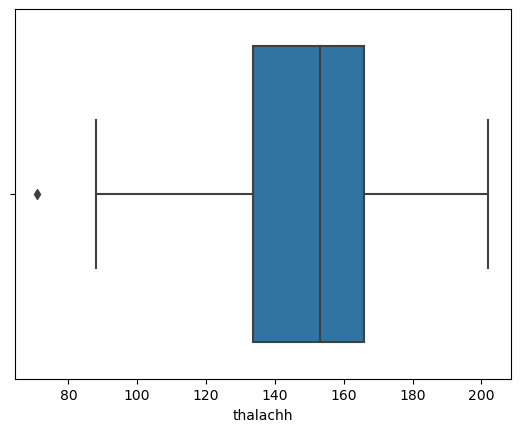

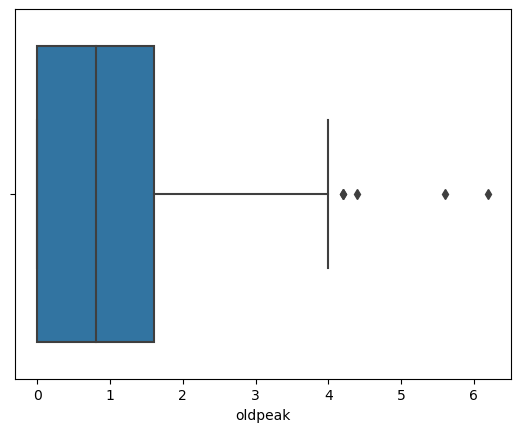

```python
continuous = ['age', 'trtbps','chol','thalachh','oldpeak']
for i in continuous:
    plt.figure() #creates a seperate figure for each count plot
    sb.boxplot(data = data_df,x = i)
```

Step 4.

Cholestrol is from 100(?) to 350, with 50% concentrated between 200 and 275 Maximum heart rate of population is spread across 90 and 200, with an emphasis from 138-163~ Previous peak(?) is majority 0,1 with rest of the population spread across 2,4 Thall rate is from 1.0 to 3.0, 50% in the range 2.0 to 3.0

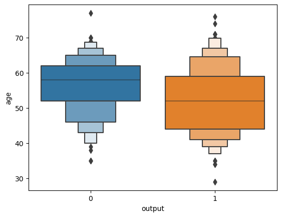

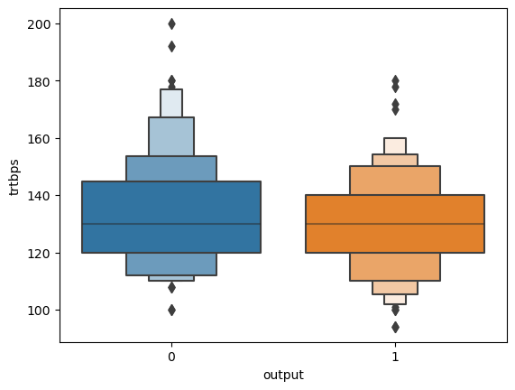

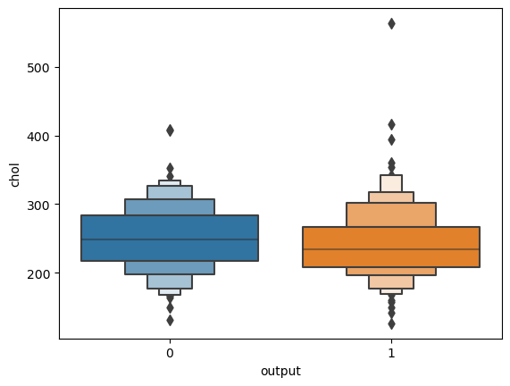

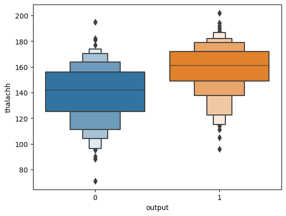

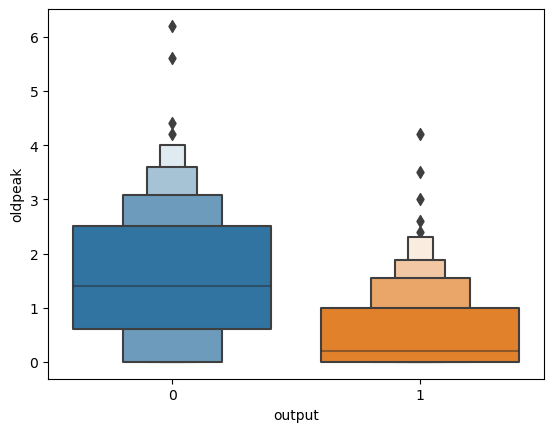

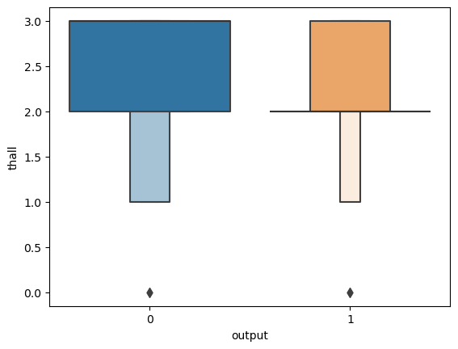

```python
continuous = ['age', 'trtbps','chol','thalachh','oldpeak','thall']
for i in continuous:
    plt.figure() #creates a seperate figure for each count plot
    sb.boxenplot(data = data_df,y = i, x = 'output')
```

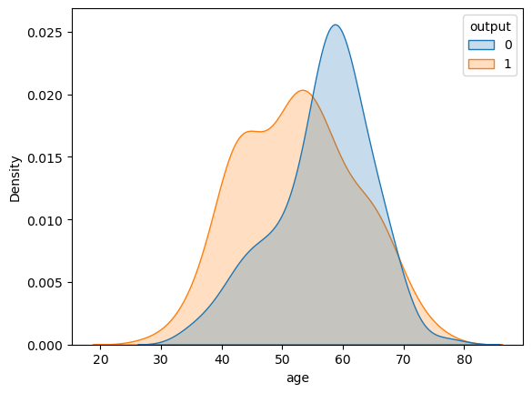

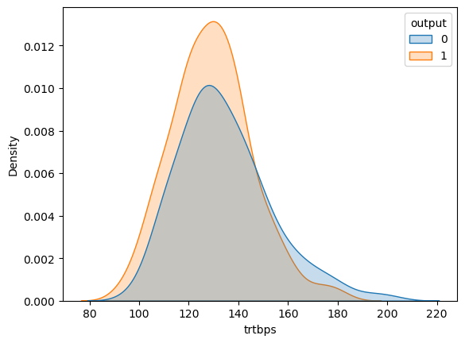

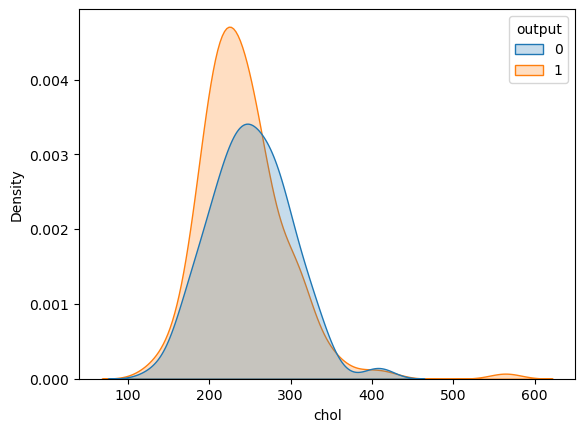

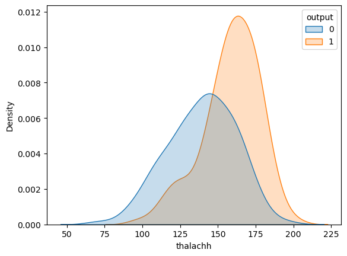

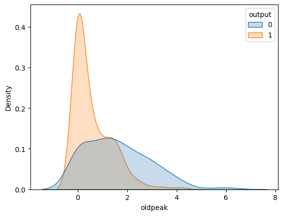

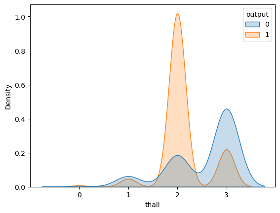

```python
continuous = ['age', 'trtbps','chol','thalachh','oldpeak','thall']
for i in continuous:
    plt.figure() #creates a seperate figure for each count plot
    sb.kdeplot(data=data_df, x=i, hue = 'output', fill = True)
```

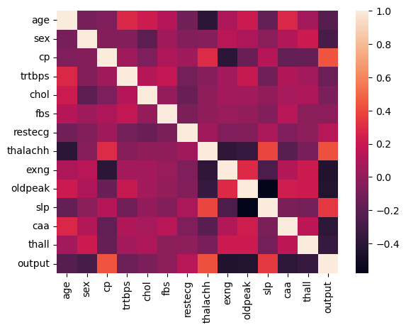

```python
sb.heatmap(data_df.corr())
```

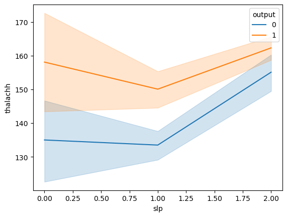

```python
sb.lineplot(data = data_df, y = 'thalachh',x = 'slp', hue = 'output')
```

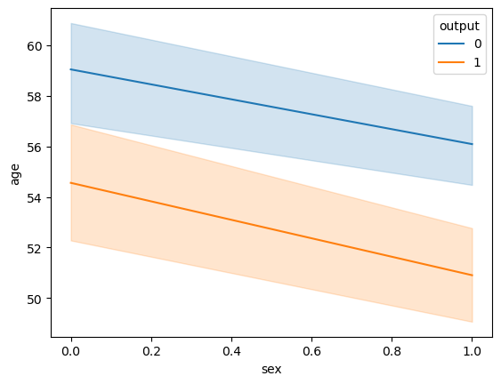

```python
sb.lineplot(data = data_df, y = 'age',x = 'sex', hue = 'output')
```

Step 7. lineplot of age and sex with output show how much of a predictor predisposed factors can give us. first lineplot shows us how drastic lifestyle factors play in the prediction of heart attack risk. I think its very interesting that personal choices are the most important contributions to reducing your risk of a heart attack, as opposed to things out of your control such as age and sex.

Step 8. Logistical and KNN are useful in solving the statement

one hot encoding changes multiple categorical variables in a single column into multiple singular columns that accept binary values. label encoding works similarly but for ordinal variables, and keeps the single column format BUT assigns all the possible values into numerical integers as opposed to binary values.

multicolinearity basically shows if two variables are describing the same factor within a dataset, this is bad because this "factor" will have increased importance within our algorithms, and give us inaccurate results as the weighing is much larger than it should be. The easiest way to detect and handle multicolinearity is to use pairplots and to drop.

scaling data is important for numerical based algorithms. if a variable uses very large integers to express values, then our algorithms will weigh these variables much higher within their formula, using a scaler such as a minmax scaler allows us to "standardize" all of our numerical data into a range of 0.00 to 1.00, ensuring that we still convey distance within our data set without having such a skewed weighing for "larger" variables.

heatmaps are non parametric while kde distribution is parametric ( using our target variable as the parameter ) our parametric algorithm can show deeper analysis but it requires us to specify our data to fit certain parameters. our nonparametric algorithm does not demand that our data fit any requirement, and thus is more flexible for different datasets, however, we may miss out on seeing the finer details that a parametric algorithm may make visible to us.

For missing values, the standard way to deal with them is to replace them with a mean/median/mode of the data depending if it is numerical/ordinal/categorical. Another way to deal with values is to delete the row associated with the missing value, however, this is not a popular method as a lot of usable information is lost this way. Lastly, we can consider using different algorithms that are built to handle these kinds of inconsistencies in our data.

Step 9.

Since all of our dataset values are in float or integer values, encoding isn't necessary.

To solve the problem statement, my two models will be K N N to classify heart attack risk or not, and logistical regression to predict the probability of a heart attack

```python
from sklearn.preprocessing import MinMaxScaler
#scaling data
scaler = MinMaxScaler()
scaler.fit(data_df)
scaled_data = scaler.transform(data_df)
scaled_df = pd.DataFrame(scaled_data, columns=data_df.columns)
```

```python
from sklearn.model_selection import train_test_split

X = scaled_df.drop('output', axis=1)  #Features
y = scaled_df['output']  #Target

# Split
X_train, X_test, y_train, y_test = train_test_split(X, y, test_size=0.3, random_state=42)
```

```python
from sklearn.linear_model import LogisticRegression
log_reg_model = LogisticRegression()
log_reg_model.fit(X_train, y_train)

y_pred1 = log_reg_model.predict(X_test)
```

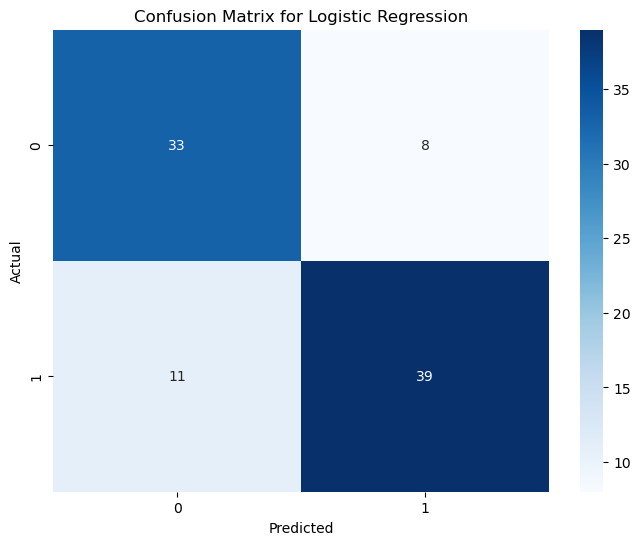

```
              precision    recall  f1-score   support

         0.0       0.75      0.80      0.78        41
         1.0       0.83      0.78      0.80        50

    accuracy                           0.79        91
   macro avg       0.79      0.79      0.79        91
weighted avg       0.79      0.79      0.79        91
```

```python
from sklearn.metrics import classification_report
from sklearn.metrics import confusion_matrix

cm = confusion_matrix(y_true = y_test, y_pred = y_pred1)
plt.figure(figsize=(8, 6))
sb.heatmap(cm, annot=True, fmt='d', cmap='Blues', cbar=True)
plt.xlabel('Predicted')
plt.ylabel('Actual')
plt.title('Confusion Matrix for Logistic Regression')
plt.show()

report = classification_report(y_test, y_pred1)
print(report)
```

```python
from sklearn.neighbors import KNeighborsClassifier

knn = KNeighborsClassifier(n_neighbors=3)
knn.fit(X_train, y_train)

y_pred2 = knn.predict(X_test)
```

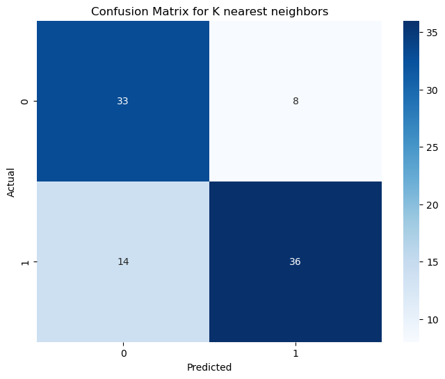

```
              precision    recall  f1-score   support

         0.0       0.70      0.80      0.75        41
         1.0       0.82      0.72      0.77        50

    accuracy                           0.76        91
   macro avg       0.76      0.76      0.76        91
weighted avg       0.77      0.76      0.76        91
```

```python
from sklearn.metrics import classification_report
from sklearn.metrics import confusion_matrix

cm = confusion_matrix(y_true = y_test, y_pred = y_pred2)
plt.figure(figsize=(8, 6))
sb.heatmap(cm, annot=True, fmt='d', cmap='Blues', cbar=True)
plt.xlabel('Predicted')
plt.ylabel('Actual')
plt.title('Confusion Matrix for K nearest neighbors')
plt.show()

report = classification_report(y_test, y_pred2)
print(report)
```

Write a conclusion (~1 paragraph) detailing the main points you discovered while exploring the data. Also include things like: Did you scale your data? If so, which scaling method did you use and why? Is there a specific reason you selected these 2 models? How did the 2 models compare against each other?

I scaled my data because KNN and Logistic Regression algorithms do not work well with unscaled data.

While I originally wanted to scale using a RobustScaler because we have many outliers in our dataset. In this context, outliers are not a bad thing to affect our dataset! Because we are trying to study the relationship between our variables and the target variable, our outliers would help show how well our variables can predict heart attacks when it comes to extreme values. I opted for the MinMax scaler as I did not not want to affect the data in any major way.

K nearest neighbors is a useful model because we have a lot of data to work with, and because this is a classification question in that we classify a patient as heart attack prone or not.

Logistic Regression is useful because this works best with probabilities, and our target variable is trying to predict the risk of a heart attack in an individual.

```python
from sklearn.model_selection import cross_val_score
from sklearn.model_selection import KFold
#cross validate with kfolds
kf = KFold(n_splits=5, shuffle=True, random_state=42)

#store scores using cross validate
log_reg_scores = cross_val_score(log_reg_model, X, y, cv=kf)
knn_scores = cross_val_score(knn, X, y, cv=kf)

# Print mean scores
print("Mean Accuracy - Logistic Regression:", log_reg_scores.mean())
print("Mean Accuracy - K Nearest Neighbors:", knn_scores.mean())
```

```
Mean Accuracy - Logistic Regression: 0.8117486338797815
Mean Accuracy - K Nearest Neighbors: 0.8217486338797816
```